# Perfect Garden Graph Week 1

Alex Ang

```r
library(tidyverse)
library(lubridate)
library(remotes)

library(gardenR)
theme_set(theme_minimal())
library(ggthemes)
library(plotly)
library(gganimate)
library(gifski)
library(transformr)
```

```r
# load the garden data
data(garden_harvest)
```

Explain the question you hope to answer and create the graph below in the Graph 1 section. For the first week, you may not have the skills quite yet to create exactly what you want to create - that’s ok! Get as close as you can, and I’ll give you feedback to help you out. You can summarize the data in any way you’d like. Add R code chunks and comment code as needed. As the weeks go by, you will continue to build on this file by putting new code in the next Graph sections. You will keep all the old code, add my feedback by copying and pasting it from moodle (found in the Grade section of moodel), and make improvements from my suggestions and from other ideas you have. Having the old code and graphs and my feedback will help you (and I) easily see the progress throughout the course.

## Graph Week 1

**Question I hope to answer: What was the most harvested vegetable by weight in Lisa’s garden in the year 2020?**

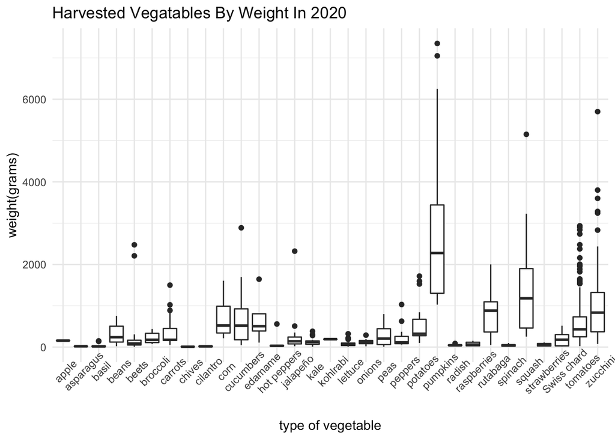

```r
garden_harvest %>%
  ggplot(aes(y=weight, x=vegetable)) +
  geom_boxplot() +
  theme(axis.text.x = element_text(angle = 45)) +
  labs(x="type of vegetable", y="weight(grams)", title="Harvested Vegatables By Weight In 2020")
```

Lisa’s feedback: (copy the feedback from moodle here)

Great start! Flip your axes so vegetable is on the y axis. Incorporate the x and y axis names into the title and then omit those labels. Reorder the boxplot from largest to smallest median harvest.

## Graph Week 2

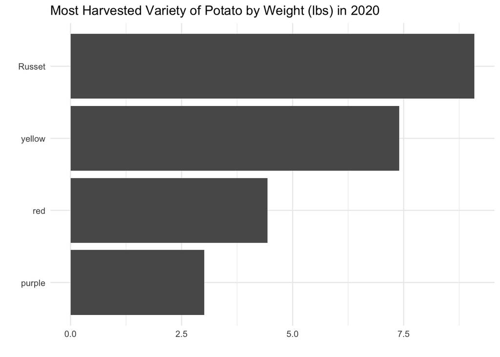

```r
garden_harvest %>%
  filter(vegetable=="potatoes") %>%
  mutate(variety=factor(variety, levels=c("purple","red", "yellow", "Russet"))) %>%
  mutate(weight_lbs=weight*0.00220462) %>%
  group_by(variety) %>%
  summarize(variety_weight=sum(weight_lbs)) %>%
  ggplot(aes(x=variety_weight, y=variety)) +
  geom_col() +
  labs(x="", y="", title= "Most Harvested Variety of Potato by Weight (lbs) in 2020")
```

According to our graph, we can see that the most harvested variety of potato in all of 2020 was the Russet potato.

Lisa’s feedback: I want you to keep building on the same graph each week - not making an entirely new one. In the end, you might combine these two graphs, but let’s focus on the one from week one. Go back and make the changes I suggested there and capitalize the first letter of each vegetable using a str_XXX() function.

## Graph Week 3

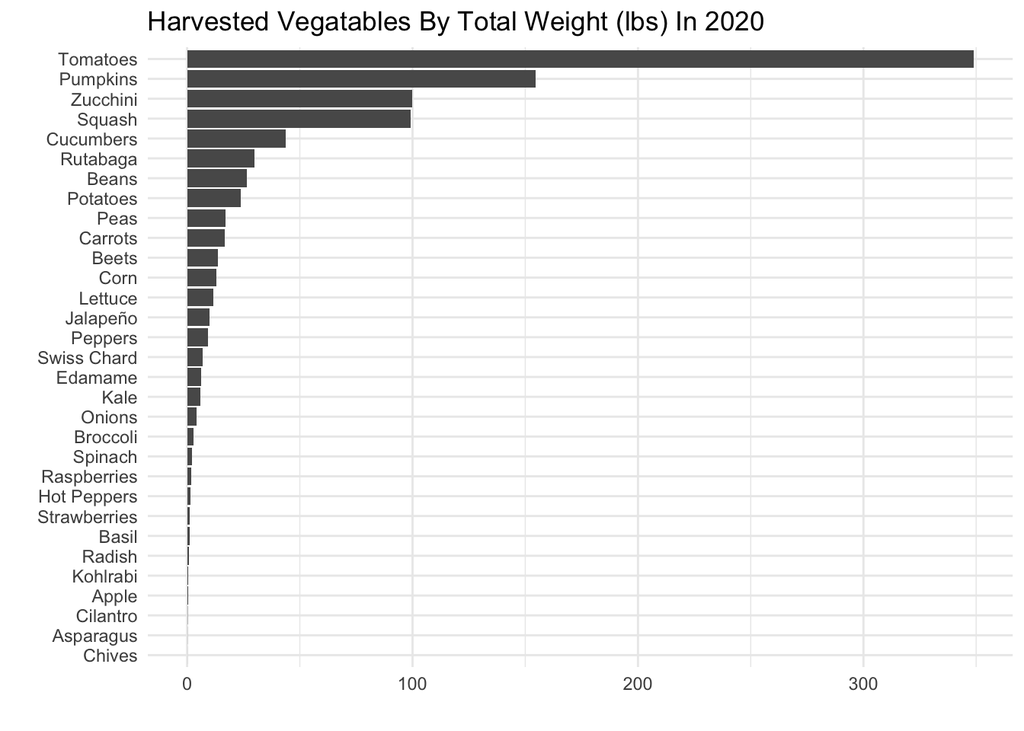

```r
garden_harvest %>%
  mutate(wght_lbs=weight*0.00220462) %>%
  group_by(vegetable) %>%
  summarize(total_wght=sum(wght_lbs)) %>%
  mutate(capital=str_to_title(vegetable)) %>%
  mutate(vegetable2=fct_reorder(capital,
                                total_wght)) %>%
  ggplot(aes(y=vegetable2,
             x=total_wght)) +
  geom_col() +
  labs(x="", y="", title="Harvested Vegatables By Total Weight (lbs) In 2020")
```

Summary of graph: After totaling the weights for each vegetable, we can see that the tomatoes were the most harvested in 2020.

Lisa’s feedback: Ok. This is looking better. Now add scale_x_continuous(expand=c(0,0)) to make the bars show up right next to the labels. Remove the horizontal grid lines using a theme argument. In addition to total weight, find the total number of days each vegetable was harvested - use the n_distinct() function, and color by that variable.

## Graph Week 4

**Question I hope to answer: What is the distribution of harvested vegetables by total weight (lbs) and total days harvested?**

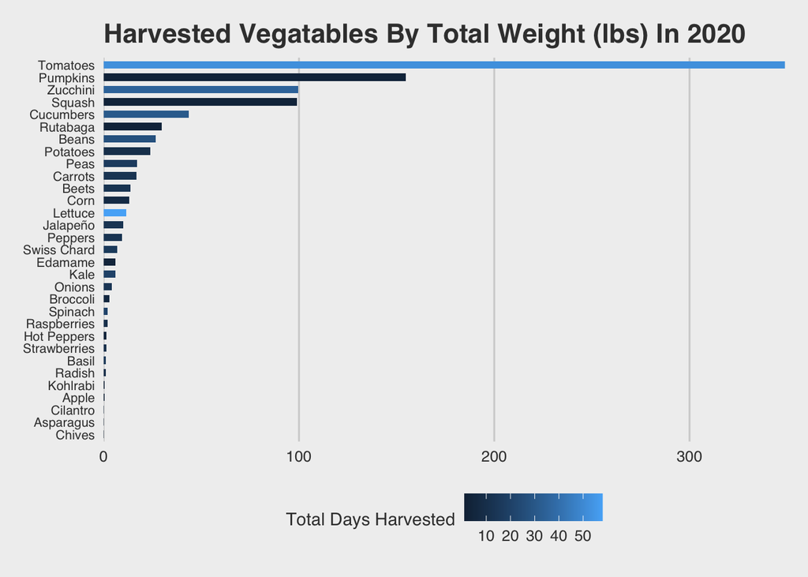

```r
garden_harvest %>%
  mutate(wght_lbs=weight*0.00220462) %>%
  group_by(vegetable) %>%
  summarize(total_wght=sum(wght_lbs),
            total_days_harv=n_distinct(date)) %>%
  mutate(capital=str_to_title(vegetable)) %>%
  mutate(vegetable2=fct_reorder(capital,
                                total_wght)) %>%
  ggplot(aes(y=vegetable2,
             x=total_wght,
             fill=total_days_harv)) +
  scale_x_continuous(expand=c(0,0)) +
  geom_col(width=0.6, position=position_dodge(width=0.5)) +
  labs(x="", y="", title="Harvested Vegatables By Total Weight (lbs) In 2020", fill="Total Days Harvested")+
  theme_fivethirtyeight() +
  theme(panel.grid.major.y = element_blank(),
        axis.text.y = element_text(size=8),
        title = element_text(size=11))
```

Summary of graph: There doesn’t seem to be a correlation between total weight of harvested vegetables and total days they were harvested.

Lisa’s feedback: This looks so nice! Move the title all the way to the left using plot.title.position = “plot” inside theme(). Add more vertical gridlines using the breaks argument in scale_x_continuous - I think at the 50’s would be good.

## Graph Week 5

Question I hope to answer: How does it vary within months of the year?

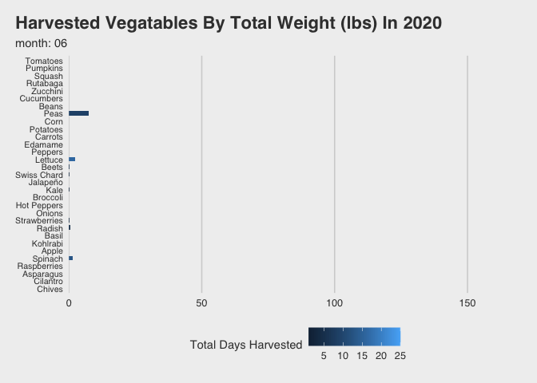

```r
perfect_garden_graph <- garden_harvest %>%
  mutate(wght_lbs=weight*0.00220462) %>%
  mutate(month=format(date, "%m")) %>%
  group_by(month, vegetable) %>%
  summarize(total_wght=sum(wght_lbs),
            total_days_harv=n_distinct(date)) %>%
  ungroup() %>%
  mutate(capital=str_to_title(vegetable)) %>%
  mutate(vegetable2=fct_reorder(capital,
                                total_wght)) %>%
  ggplot(aes(y=vegetable2,
             x=total_wght,
             fill=total_days_harv)) +

  scale_x_continuous(expand=c(0,0), breaks=c(0,50,100,150,200,250,300,350)) +
  geom_col(width=0.6, position=position_dodge(width=0.5)) +
  labs(x="", y="", title="Harvested Vegatables By Total Weight (lbs) In 2020", fill="Total Days Harvested", subtitle = "month: {closest_state}")+
  theme_fivethirtyeight() +
  theme(panel.grid.major.y = element_blank(),
        axis.text.y = element_text(size=8),
        title = element_text(size=11),
        plot.title.position="plot") +

  transition_states(month, transition_length=2, state_length = 3) +
  exit_fade()

animate(perfect_garden_graph, duration=20)
```

```r
anim_save("perfect_garden_graph.gif")
```